# Reproducible Research: Week 2 Assignment

Nitin Singh

27 February 2017

# Introduction

With the advancement of technology and the growth of the big data movement, it is now possible to collect a large amount of data about personal movement using activity monitoring devices. Such examples are: Fitbit, Nike Fuelband, or Jawbone Up. These kinds of devices are part of the “quantified self” movement: those who measurements about themselves on a regular basis in order to improve their health, find patterns in their behaviour, or because they are simply technology geeks. However, these data remain severely underused due to the fact that the raw data are hard to obtain and there is a lack of statistical methods and software for processing and interpreting the data.

This assignment makes use of data from a personal activity monitoring device. This device collects data at 5 minute intervals throughout the day. The data consists of two months of data from an anonymous individual collected during the months of October and November 2012 and include the number of steps taken in 5 minute intervals each day.

Based on the given data, we carry out some basic exploratory data analysis and answer some questions. The overall goal of this assignment is to make some basic exploratory data analysis to assess some activity patterns with regards to the anonymous individual’s walking patterns. For each day, there are readings taken at particular 5-minute intervals. These readings correspond to the number of steps taken by the anonymous individual between the previous 5-minute interval to the current 5-minute interval.

# Data Layout

As such, the data provided to us is a 3-column data frame:

1. Column 1 - steps: Indicates the number of steps taken during a neighbouring 5-minute interval (between 5 minutes and 10 minutes, 10 minutes and 15 minutes, etc.). There were some instances where there were no readings taken, most likely due to the fact that the subject was sleeping or the device was shut off. These are coded in as NA values.
2. Column 2 - date: Indicates the date at which the measurement was taken. This is in the YYYY-MM-DD format.
3. Column 3 - interval: The aforementioned ID that determines at which 5-minute interval the reading was taken at (5, 10, 15, 20, etc.)

## Loading and Preprocessing Dataset

Before we begin, it is imperative that the reader set the working directory to be where this R Markdown file (and subsequently all of the data for the analysis) is located. This can be done with the setwd() command.

The first thing we obviously need to do is read in the data and clean it up so that it is presentable for analysis. Dr. Roger Peng, being the most generous person on the planet, has already cleaned up the data for us. However, the only thing that will be done is to convert the dates into a POSIXlt class for easier processing. The data have been extracted from .zip archive file and all we need to do is to read the datafile activity.csv in using read.csv(). After, the dates will be transformed into the POSIXlt class.

```r
data <- read.csv("activity.csv")
head(data)
```

```
##   steps       date interval
## 1    NA 2012-10-01        0
## 2    NA 2012-10-01        5
## 3    NA 2012-10-01       10
## 4    NA 2012-10-01       15
## 5    NA 2012-10-01       20
## 6    NA 2012-10-01       25
```

```r
# Turn the data$date into a POSIXIt class,
# allows for easier handling & transformations
dates_posixit <- strptime(data$date, "%Y-%m-%d")
data$date <- dates_posixit

# Record unique values for future processing
uniqueDates <- unique(dates_posixit)
uniqueIntervals <- unique(data$interval)
```

As for uniqueDates and uniqueIntervals, these are variables that store a list of all possible dates and intervals. These will primarily be used to help plot our necessary data and for data processing.

## What is the mean total number of steps taken per day?

First, let’s plot a histogram of the total number of steps taken for each day. Before we do this, let’s split up the data into individual data frames where each data frame represents the data for a particular day. After this, we will create a vector that accumulates all of the steps taken for each day and let it get stored into a vector. Each element in this vector represents the total number of steps taken for a particular day (61 in total). It should be noted that NA values will be ignored for the time being. After, we will plot a histogram where the x-axis represents the particular day in question, while the y-axis denotes how many steps were taken in total for each day. We will also calculate what the mean and median number of steps per day were as well.

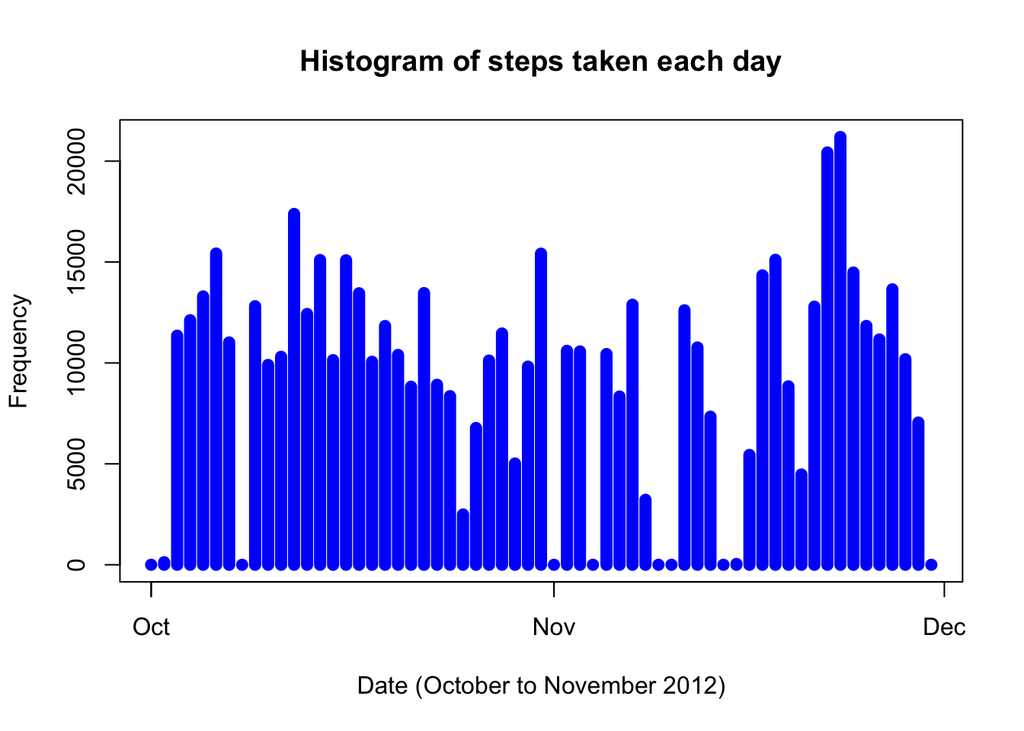

```r
steps_split_day <- split(data$steps, dates_posixit$yday)
steps_split_day_sum <- sapply(steps_split_day, sum, na.rm = TRUE)
plot(uniqueDates, steps_split_day_sum, main="Histogram of steps taken each day",
     xlab="Date (October to November 2012)", ylab="Frequency", type="h", lwd=8, col="blue")
```

The mean and median steps per day are:

```r
steps_split_day_mean <- sapply(steps_split_day, mean, na.rm = TRUE)
steps_split_day_median <- sapply(steps_split_day, median, na.rm = TRUE)
steps_split_day_mean_df <- data.frame(date=uniqueDates,
                                 mean_steps=steps_split_day_mean, row.names=NULL)
steps_split_day_median_df <- data.frame(date=uniqueDates,
                                 median_steps=steps_split_day_median, row.names=NULL)
head(steps_split_day_mean_df)
```

```
##         date mean_steps
## 1 2012-10-01        NaN
## 2 2012-10-02    0.43750
## 3 2012-10-03   39.41667
## 4 2012-10-04   42.06944
## 5 2012-10-05   46.15972
## 6 2012-10-06   53.54167
```

```r
head(steps_split_day_median_df)
```

```
##         date median_steps
## 1 2012-10-01           NA
## 2 2012-10-02            0
## 3 2012-10-03            0
## 4 2012-10-04            0
## 5 2012-10-05            0
## 6 2012-10-06            0
```

## What is the average daily activity pattern?

What we now need to do is split up this data again so that individual data frames represent the steps taken over each time interval. As such, there will be a data frame for interval 5, another data frame for interval 10 and so on. Once we extract out these individual data frames, we thus compute the mean for each time interval. It is imperative to note that we again will ignore NA values. We will thus plot the data as a time-series plot (of type=“l”). Once we have done this, we will locate where in the time-series plot the maximum is located and will draw a red vertical line to denote this location:

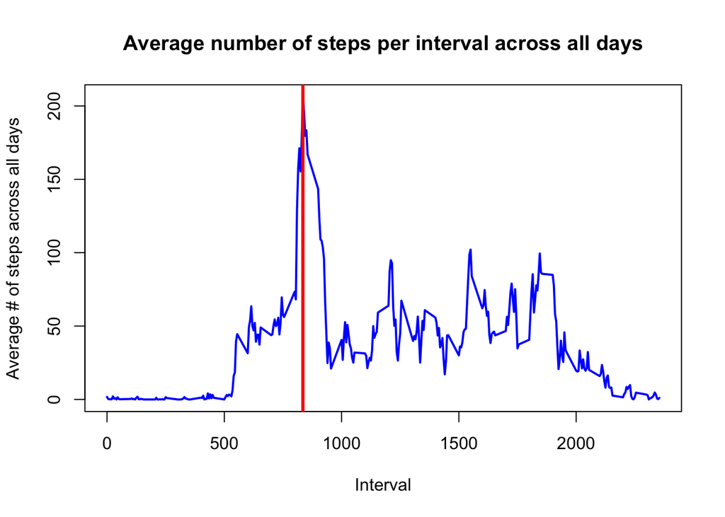

```r
steps_split_interval <- split(data$steps, data$interval)

# Find the average amount of steps per time interval - ignore NA values
steps_split_interval_mean <- sapply(steps_split_interval, mean, na.rm=TRUE)

# Plot the time-series graph
plot(uniqueIntervals, steps_split_interval_mean, type="l",
     main="Average number of steps per interval across all days",
     xlab="Interval", ylab="Average # of steps across all days",
     lwd=2, col="blue")

steps_split_interval_max = max(steps_split_interval_mean, na.rm = TRUE)
steps_split_interval_maxIndex <- as.numeric(which(steps_split_interval_mean
                                                   == steps_split_interval_max))

maxInterval <- uniqueIntervals[steps_split_interval_maxIndex]
abline(v=maxInterval, col="red", lwd=3)
```

## Imputing the missing values.

The strategy that we will use to fill in the missing values in the data set is to replace all NA values with the mean of that particular 5-minute interval the observation falls on. Now that we have devised this strategy, let’s replace all of the NA values with the aforementioned strategy.

```r
steps_split_interval_mean[is.nan(steps_split_interval_mean)] <- 0
steps_split_interval_mean_replicated <- rep(steps_split_interval_mean, 61)
rawSteps <- data$steps
stepsNA <- is.na(rawSteps)
rawSteps[stepsNA] <- steps_split_interval_mean_replicated[stepsNA]
dataNew <- data
dataNew$steps <- rawSteps
```

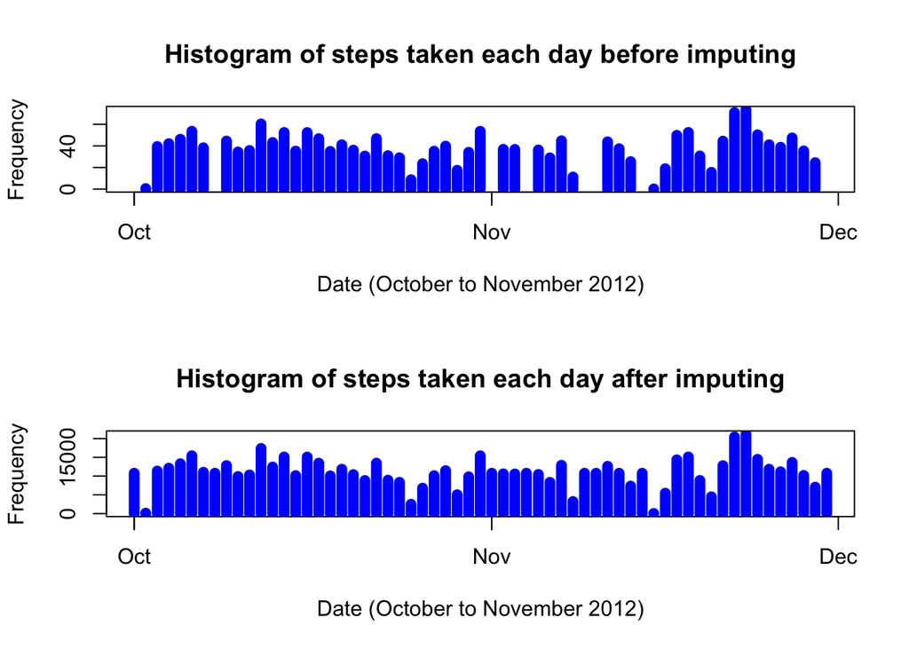

```r
steps_split_day_new <- split(dataNew$steps, dates_posixit$yday)
steps_split_day_new_mean <- sapply(steps_split_day_new, sum)
par(mfcol=c(2,1))

# Plot the original histogram first
plot(uniqueDates, steps_split_day_mean, main="Histogram of steps taken each day before imputing",
     xlab="Date (October to November 2012)", ylab="Frequency", type="h", lwd=8, col="blue")

# Plot the modified histogram after
plot(uniqueDates, steps_split_day_new_mean, main="Histogram of steps taken each day after imputing",
     xlab="Date (October to November 2012)", ylab="Frequency", type="h", lwd=8, col="blue")
```

The new mean and median steps per day are:

```r
steps_split_day_new_mean <- sapply(steps_split_day_new, mean, na.rm = TRUE)
steps_split_day_new_median <- sapply(steps_split_day_new, median, na.rm = TRUE)
steps_split_day_new_mean_df <- data.frame(date=uniqueDates,
                                 mean_steps=steps_split_day_new_mean, row.names=NULL)
steps_split_day_new_median_df <- data.frame(date=uniqueDates,
                                 median_steps=steps_split_day_new_median, row.names=NULL)
head(steps_split_day_new_mean_df)
```

```
##         date mean_steps
## 1 2012-10-01   37.38260
## 2 2012-10-02    0.43750
## 3 2012-10-03   39.41667
## 4 2012-10-04   42.06944
## 5 2012-10-05   46.15972
## 6 2012-10-06   53.54167
```

```r
head(steps_split_day_new_median_df)
```

```
##         date median_steps
## 1 2012-10-01     34.11321
## 2 2012-10-02      0.00000
## 3 2012-10-03      0.00000
## 4 2012-10-04      0.00000
## 5 2012-10-05      0.00000
## 6 2012-10-06      0.00000
```

# Are there differences in activity patterns during the weekdays and the weekends ?

With the new data set we have just created, we are going to split up the data into two data frames - one data frame consists of all steps taken on a weekday, while the other data frame consists of all steps taken on a weekend. The following R code illustrates this for us:

```r
wdays <- dates_posixit$wday
type_day <- rep(0, 17568)

# set the factor 1 for a weekday and 2 for a weekend
type_day[wdays >= 1 & wdays <= 5] <- 1
type_day[wdays == 0 | wdays == 6] <- 2

# create a new factor variable that has labels weekend & weekdays
day_factor <- factor(type_day, levels=c(1,2), labels=
                    c("Weekdays", "Weekends"))

dataNew$typeofday <- day_factor

dataNew_weekdays <- dataNew[dataNew$typeofday == "Weekdays",]
dataNew_weekends <- dataNew[dataNew$typeofday == "Weekends",]
```

Now that we have accomplished this, let’s split up the data for each data frame so that we will have two sets of individual data frames. One set is for weekdays and within this data frame are individual data frames. Each data frame contains the steps for each interval recorded on a weekday. The other set is for weekends, and within this data frame are individual data frames. Like previously, each data frame here contains the steps for each interval recorded on a weekday. Once we have these two sets of data frames, we will now calculate the mean amount of steps for each interval for the weekdays data frame and weekends data frame. This will result in two vectors - one for the weekdays and the other for weekends. The following R code does this for us:

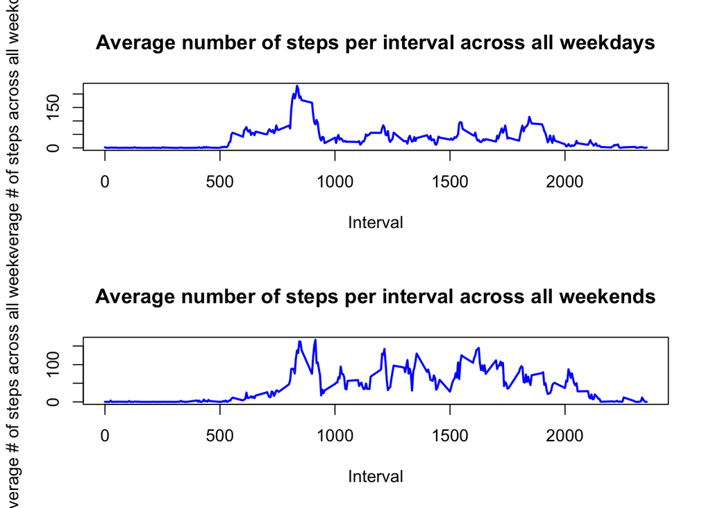

```r
step_split_dataNew_weekdays <- split(dataNew_weekdays$steps, dataNew_weekdays$interval)
step_split_dataNew_weekends <- split(dataNew_weekends$steps, dataNew_weekends$interval)

step_split_dataNew_weekdays_mean <- sapply(step_split_dataNew_weekdays, mean)
step_split_dataNew_weekends_mean <- sapply(step_split_dataNew_weekends, mean)

par(mfcol=c(2,1))
plot(uniqueIntervals, step_split_dataNew_weekdays_mean, type="l",
     main="Average number of steps per interval across all weekdays",
     xlab="Interval", ylab="Average # of steps across all weekdays",
     lwd=2, col="blue")
plot(uniqueIntervals, step_split_dataNew_weekends_mean, type="l",
     main="Average number of steps per interval across all weekends",
     xlab="Interval", ylab="Average # of steps across all weekends",
     lwd=2, col="blue")
```

What is interesting about this plot is that it very much sums up the activity that any normal person would undergo depending on whether it is a weekday or weekend. For both days, the intervals between 0 and about 525 are uniform. This most likely represents when the subject was sleeping. The differences start at between 525 and roughly 800. On the weekdays, movement is most likely attributed to the subject getting ready to go to work or starting their day. On the weekends, movement is less frequent. This could be attributed to the subject sleeping in and perhaps making breakfast to start their day.

There is a huge jump at roughly 830 for the weekdays. This could be attributed to the subject walking or making their way to work. On the weekends this behaviour is mimicked as well, perhaps due to making their way to begin engaging in some extracurricular activities that the subject is engaged in. Now where it really gets different is at roughly the 1000 mark. On the weekdays, this could be reflected with the subject being at work and there is not much movement. A good indication of this behaviour could be attributed to the fact that the subject has a low stress job that requires minimal movement. On the weekends, the behaviour varies wildly. This could be attributed to the extra amount of movement required to engage in such extracurricular activities.

Where it starts to become similar again is at roughly the 1700 mark. This could mean that during the weekdays, the subject is getting ready to head home for the day which is why there is an increased amount of moment in comparison to the interval between 1000 to 1700. At the same time with the weekends, there is a relative amount of increased moment after the 1700 mark but it could reflect that at this time of day, the subject may be socializing.

All in all, this seems to reflect the behaviour of an individual going through a normal work day during the weekdays, and having a relaxing time on the weekends.